Vehicle Classification Using Silhouette features

Author: Suresh Venkatesan

Objective: Classify a vehicle into one of three categories using a set of features extracted from the silhouette

# Import necessary libraries

```python
import numpy as np
import pandas as pd
import matplotlib.pyplot as plt
import matplotlib as mpl
import seaborn as sns
import time
sns.set(color_codes = True)
%matplotlib inline

from scipy import stats

# Preprocessing libraries
from sklearn.preprocessing import MinMaxScaler # MinMax Scaler
from sklearn.preprocessing import StandardScaler # Standard Scaler
from sklearn.preprocessing import RobustScaler # Robust Scaler

from sklearn.decomposition import PCA # Principal Components Analysis

# Model libraries
from sklearn.linear_model import LogisticRegression # Logistic Regression Classifier
from sklearn.neighbors import KNeighborsClassifier # KNN classifier
from sklearn.naive_bayes import GaussianNB # Gaussian Naive Bayes classifier
from sklearn.svm import LinearSVC # Linear Support Vector Classifier
from sklearn.svm import SVC # Support Vector Machine classifer
from sklearn.tree import DecisionTreeClassifier # Decision tree classifier
from sklearn.ensemble import BaggingClassifier # Bagging Classifier
from sklearn.ensemble import RandomForestClassifier # Random Forest Classifier
from sklearn.ensemble import AdaBoostClassifier # Adaptive Boosting Classifier
from sklearn.ensemble import GradientBoostingClassifier # Gradient Boosting Classifier

# Model selection libraries
from sklearn.model_selection import train_test_split # Split data into training and test sets
from sklearn.model_selection import GridSearchCV # Exhaustive grid search on hyper parameters.
from sklearn.model_selection import RandomizedSearchCV # Randomized search on hyper parameters.

# Metric evaluation libraries
from sklearn.metrics import classification_report # Generate classification report.
from sklearn.metrics import accuracy_score # Classification accuracy metric

# Pipelines
from sklearn.pipeline import Pipeline # Build pipelines
from sklearn.pipeline import make_pipeline # Construct a Pipeline from the given estimators.
```

```python
# Set some plotting and printing ptions
mpl.rc('axes', labelsize = 30)
mpl.rc('axes', titlesize = 30)
mpl.rc('xtick', labelsize = 20)
mpl.rc('ytick', labelsize = 20)
mpl.rc('legend', fontsize = 20)
mpl.rc('figure', titlesize = 40)

pd.set_option('precision', 4) # Print 4 decimal places for all output parameters
```

# Helper Functions

- In this section, we will define multiple helper functions which will be used later in the code for fitting models, evaluating and plotting various metrics.

## Five-Point Summary, Outliers, Skew

- This function will print a summary of the five-point summary, number of outliers and skew of all numeric columns.

```python
def fps_out_skew(df_orig, numer_cols):

    """
    Function to print summary of the five-point summary, number of outliers
    and skew of all numeric columns.

    Arguments:
        df_orig - Input Dataframe.
        numer_cols - List of all numeric columns.

    Returns:
        fps_out_skew_df - Dataframe with summary of the five-point summary, number of outliers
                          and skew of all numeric columns.

    """


    fps_out_skew_df = df_orig[numer_cols].quantile(q = [0, 0.25, 0.5, 0.75, 1], axis = 0).transpose()
    quart_cols = {0.00: "Min", 0.25: 'Q1', 0.5: "Q2", 0.75: "Q3", 1.00: "Max"}
    fps_out_skew_df.rename(columns = quart_cols, inplace = True)
    fps_out_skew_df['IQR'] = fps_out_skew_df['Q3'] - fps_out_skew_df['Q1']
    fps_out_skew_df['skew'] = stats.skew(df_orig[numer_cols])
    fps_out_skew_df['out_low'] = 0
    fps_out_skew_df['out_high'] = 0
    out_min_thresh = fps_out_skew_df['Q1'] - 1.5 * fps_out_skew_df['IQR']
    out_max_thresh = fps_out_skew_df['Q3'] + 1.5 * fps_out_skew_df['IQR']
    for col in numer_cols:
        fps_out_skew_df.loc[col, 'out_low'] = ((df_orig[col] < out_min_thresh[col]).sum())
        fps_out_skew_df.loc[col, 'out_high'] = ((df_orig[col] > out_max_thresh[col]).sum())

    fps_out_skew_df['out_tot'] = fps_out_skew_df['out_low'] + fps_out_skew_df['out_high']

    return fps_out_skew_df
```

## Init classifier dictionary function

- This function is used to define all classifiers and collect them together into a dictionary. The following classifiers are evaluated here:
  - **Logistic Regression.**
  - **Gaussian Naive Bayes model.**
  - **KNN classifier.**
  - **Support Vector Machine classifier with Polynomial Kernel.**
  - **Support Vector Machine Classifier with RBF Kernel.**
  - **Decision Tree Classifier.**
  - **Bagging Classifier.**
  - **Random Forest Classifier.**
  - **Adaptive Boosting Classifier.**
  - **Gradient Boosting Classifier.**

```python
def clf_define():

    """
    Function to define all classifiers and collect into a dictionary

    Arguments:
        None

    Returns:
        clfs - Dictionary of classifiers.
               Key of clfs = S.No of classifier
               Each entry of clfs is a list with the classifier object,
               name of the classifier, type of the classifier,
               coarse parameter list to do grid search,
               fine parameter list to do grid search.

    """
    clf_ind = -1 # Initialize index of classifiers
    clfs = dict() # Initialize dictionary of classifiers
    clf = [] # List to store classifier objects
    clf_name = [] # List to store classifier names
    clf_type = [] # List to store classifier types

    # Logistic regression.
    clf_ind += 1
    clf.append(LogisticRegression(solver = 'liblinear'))
    clf_name.append('Logistic_Regression_Without_Class_Weights')
    clf_type.append('Linear')
    param_grid_coarse = {'C': [0.01, 0.05, 0.1, 0.5, 1, 5, 10, 25, 50, 75, 100, 500, 1000]}
    param_grid_fine = {'C': list(range(1, 11, 1))}
    clfs.update({clf_ind: [clf[clf_ind], clf_name[clf_ind], clf_type[clf_ind],\
                             param_grid_coarse, param_grid_fine]})

    # Gaussian Naive Bayes model
    clf_ind += 1
    clf.append(GaussianNB())
    clf_name.append('Gaussian_Naive_Bayes')
    clf_type.append('Naive_Bayes')
    param_grid_coarse = {}
    param_grid_fine = {}
    clfs.update({clf_ind: [clf[clf_ind], clf_name[clf_ind], clf_type[clf_ind],\
                             param_grid_coarse, param_grid_fine]})

    # KNN classifier.
    clf_ind += 1
    clf.append(KNeighborsClassifier())
    clf_name.append('K_Nearest_Neighbors')
    clf_type.append('KNN')
    param_grid_coarse = {'n_neighbors': list(range(1, 21, 1))}
    param_grid_fine = {}
    clfs.update({clf_ind: [clf[clf_ind], clf_name[clf_ind], clf_type[clf_ind],\
                             param_grid_coarse, param_grid_fine]})

    # Support vector machine classifier with polynomial kernel
    clf_ind += 1
    clf.append(SVC(kernel='poly'))
    clf_name.append('SVM_With_Poly_Kernel')
    clf_type.append('SVM')
    param_grid_coarse = {'C': [0.01, 0.1, 1, 10, 100, 1000],
                         'degree': list(range(3, 7, 1)),
                         'gamma': [0.001, 0.01, 0.1, 1, 10, 100, 1000]
                        }
    param_grid_fine = {'C': [0.01, 0.1, 1, 10, 100],
                         'degree': list(range(3, 4, 1)),
                         'gamma': [0.1, 0.5, 1, 5]
                        }
    clfs.update({clf_ind: [clf[clf_ind], clf_name[clf_ind], clf_type[clf_ind],\
                             param_grid_coarse, param_grid_fine]})

    # Support vector machine classifier with gaussian kernel
    clf_ind += 1
    clf.append(SVC(kernel='rbf'))
    clf_name.append('SVM_With_RBF_Kernel')
    clf_type.append('SVM')
    param_grid_coarse = {'C': [0.01, 0.1, 1, 10, 100, 1000],
                         'gamma': [0.001, 0.01, 0.1, 1, 5, 10, 100, 1000]
                        }
    param_grid_fine = {'C': [1, 10, 100, 1000],
                         'gamma': [1, 5, 10, 20, 30, 50, 75, 100]
                        }
    clfs.update({clf_ind: [clf[clf_ind], clf_name[clf_ind], clf_type[clf_ind],\
                             param_grid_coarse, param_grid_fine]})

    # Decision Tree classifier
    clf_ind += 1
    clf.append(DecisionTreeClassifier(random_state = 0))
    clf_name.append('Decision_Tree_Classifier')
    clf_type.append('tree')
    param_grid_coarse = {'criterion': ['gini', 'entropy'],
                         'max_depth': list(range(2, 20, 2)),
                         'min_samples_split': list(range(2, 10, 1))
                        }
    param_grid_fine = {}
    clfs.update({clf_ind: [clf[clf_ind], clf_name[clf_ind], clf_type[clf_ind],\
                             param_grid_coarse, param_grid_fine]})

    # Bagging classifier
    clf_ind += 1
    clf.append(BaggingClassifier())
    clf_name.append('Bagging_Classifier')
    clf_type.append('ensemble')
    param_grid_coarse = {'n_estimators': [25, 50, 100, 150, 200, 250, 300, 350, 400]}
    param_grid_fine = {}
    clfs.update({clf_ind: [clf[clf_ind], clf_name[clf_ind], clf_type[clf_ind],\
                             param_grid_coarse, param_grid_fine]})

    # Random forest classifier
    clf_ind += 1
    clf.append(RandomForestClassifier(random_state = 0))
    clf_name.append('Random_Forest_Classifer')
    clf_type.append('ensemble')
    param_grid_coarse = {'n_estimators': list(range(20, 210, 20)),
                         'criterion': ['gini', 'entropy'],
                         'min_samples_split': list(range(2, 7, 1)),
                         'max_features': list(range(2, 7, 1))
                        }
    param_grid_fine = {'n_estimators': list(range(60, 210, 20)),
                       'criterion': ['entropy'],
                       'min_samples_split': list(range(2, 4, 1)),
                       'max_features': list(range(2, 5, 1))
                        }
    clfs.update({clf_ind: [clf[clf_ind], clf_name[clf_ind], clf_type[clf_ind],\
                             param_grid_coarse, param_grid_fine]})

    # Adaptive boosting classifier
    clf_ind += 1
    clf.append(AdaBoostClassifier(random_state = 0))
    clf_name.append('Adaptive_Boosting_Classifier')
    clf_type.append('ensemble')
    param_grid_coarse = {'n_estimators': list(range(20, 310, 20))}
    param_grid_fine = {'n_estimators': list(range(750, 850, 10))}
    clfs.update({clf_ind: [clf[clf_ind], clf_name[clf_ind], clf_type[clf_ind],\
                             param_grid_coarse, param_grid_fine]})

    # Gradient boosting classifier
    clf_ind += 1
    clf.append(GradientBoostingClassifier(random_state = 0))
    clf_name.append('Gradient_Boosting_Classifier')
    clf_type.append('ensemble')
    param_grid_coarse = {'n_estimators': list(range(20, 310, 20)),
                         'max_depth': list(range(1, 3, 1))
                        }
    param_grid_fine = {'n_estimators': list(range(100, 310, 20)),
                         'max_depth': list(range(1, 5, 1))
                        }
    clfs.update({clf_ind: [clf[clf_ind], clf_name[clf_ind], clf_type[clf_ind],\
                             param_grid_coarse, param_grid_fine]})

    return clfs
```

## Grid / Random Search CV and Model Fit

- This function is used to do a Grid Search CV or Random Search CV on all the classifiers.

```python
def model_fit(clfs, clfs_fit, X_train, y_train, pre_proc, cv_type, cf, num_cv, num_iter):

    """
    Function to do a grid search CV or random search CV on all classifiers

    Arguments:
        clfs - Dictionary of classifiers.
               Key of clfs = S.No of classifier
               Each entry of clfs is a list with the classifier object,
               name of the classifier, type of the classifier,
               coarse parameter list to do grid search,
               fine parameter list to do grid search.
        clfs_fit - Input list of fitted GridSearchCV or RandomSearchCV objects.
        X_train - Training set features
        y_train - Training set labels
        pre_proc - List containing pre-processing steps to apply for each classifiers.
                 - Each element of pre_proc is a list which contains the list of pre-processing
                   steps to apply for that particular classifier.
        cv_type - List containing type of search to do for each classifier.
                  0: Don't perform either GridSearchCV or RandomSearchCV. In this case,
                     clfs_fit for that particular classifier will not be modified.
                  1: Perform GridSearchCV and return updated clfs_fit for that classifier.
                  2: Perform RandomSearchCV and return updated clfs_fit for that classifier.
        cf - List with details on whether to perform coarse or fine search for each classifier.
             0: Perform coarse search using param_grid_coarse
             1: Perform fine search using param_grid_fine
        num_cv - List with number of cross-validation runs to do on each classifier.
        num_iter - List with number of parameter settings to be sampled for each classifier
                   if RandomizedSearchCV is run for that classifier.

    Returns:
        clfs_fit - Updated list of fitted GridSearchCV or RandomSearchCV objects.

    """

    # Iterate through all classifiers
    for ind in range(len(clfs)):
        if (cv_type[ind] != 0):
            # Create pipeline of scaler and classifier
            clf_steps = pre_proc[ind].copy()
            clf_steps.append(('clf', clfs[ind][0]))
            pipe = Pipeline(clf_steps)

            # Create updated parameter grid for use in pipeline depending on whether coarse or
            # fine search is required.
            if (cf[ind] == 0):
                upd_param_grid = dict([(('clf' + '__' + keys), values)\
                                       for keys, values in clfs[ind][3].items()])
            elif (cf[ind] == 1):
                upd_param_grid = dict([(('clf' + '__' + keys), values)\
                                       for keys, values in clfs[ind][4].items()])

        if (cv_type[ind] == 1):
            grids = GridSearchCV(pipe, upd_param_grid, cv = num_cv[ind], return_train_score = True,\
                                 verbose = 0)
            print("Fitting Classifier %d...." %ind, end = ', ')
            tic = time.process_time() # Set clock timer
            grids.fit(X_train, y_train)
            toc = time.process_time() # Stop clock timer
            print("Fitting Completed. Elapsed time = %0.2f seconds" %(toc - tic))
            clfs_fit[ind] = grids
        elif (cv_type[ind] == 2):
            rands = RandomizedSearchCV(pipe, upd_param_grid, n_iter = num_iter[ind],\
                                       cv = num_cv[ind], return_train_score = True)
            print("Fitting Classifier %d...." %ind, end = ', ')
            tic = time.process_time() # Set clock timer
            rands.fit(X_train, y_train)
            toc = time.process_time() # Stop clock timer
            print("Fitting Completed. Elapsed time = %0.2f seconds" %(toc - tic))
            clfs_fit[ind] = rands

    return clfs_fit
```

## CV Results summary

- This function will print a summary of the CV search results for a given classifier.

```python
def cv_results_summary(clfs_fit, clf_ind, print_res = False):

    """
    Function to print summary of grid search CV or random search CV on a given classifier.

    Arguments:
        clfs_fit - List of fitted GridSearchCV or RandomSearchCV objects.
        clf_ind - Index of classifier for which results need to be printed.
        print_res - Print summary of results if print_res = True

    Returns:
        cv_results_df - Summary of results from CV search.

    """

    # Load cv_results for the given classifier into a dataframe
    cv_results_df = pd.DataFrame(clfs_fit[clf_ind].cv_results_)

    # Select only important columns
    cols = []
    for ind, val in enumerate(list(cv_results_df.columns)):
        if (('param_' in val) or ('mean_t' in val) or ('rank_' in val)):
            cols.append(val)
    cv_results_df = cv_results_df[cols]

    if print_res:
        # Print results summary
        display(cv_results_df)

    return cv_results_df
```

## Evaluate Models

- This function will evaluate the classification accuracy on all the fitted models and print the summary.

```python
def model_eval_mc(clfs, clfs_fit, X_train, y_train, X_test, y_test, print_res = False):

    """
    Function to evaluate all parameters on training and test sets.
    All outputs are collected into a DataFrame and printed to screen.

    Arguments:
        clfs - Dictionary of classifiers.
               Key of clfs = S.No of classifier
               Each entry of clfs is a list with the classifier object,
               name of the classifier, type of the classifier,
               coarse parameter list to do grid search,
               fine parameter list to do grid search.
        clfs_fit - List of fitted GridSearchCV or RandomSearchCV objects.
        X_train - Training set features
        y_train - Training set labels
        X_test - Test set features
        y_test - Test set output
        print_res - If true, print summary of results on training set

    Returns:
        model_summary - Dataframe with results summary of training set

    """

    # Initialize classifier names list. Will be used as index for output DataFrame
    clf_names = []

    # Arrays to store output parameters
    clf_acc_cv_tr_te = np.zeros((len(clfs), 3))

    # Iterate through all classifiers in 'clfs'
    for ind in range(len(clfs)):

        # Append classifier name to clf_names array
        clf_names.append(clfs[ind][1])

        # Evaluate best CV score for this classifier
        clf_acc_cv_tr_te[ind, 0] = 100 * (clfs_fit[ind].best_score_)

        # Extract best estimator
        clf = clfs_fit[ind].best_estimator_

        # Obtain scores for training and test sets
        clf_acc_cv_tr_te[ind, 1] = 100 * (clf.score(X_train, y_train))
        clf_acc_cv_tr_te[ind, 2] = 100 * (clf.score(X_test, y_test))

    # Club results of all classifiers into a single dataframe
    model_summary = pd.DataFrame(clf_acc_cv_tr_te, index = clf_names,\
                             columns = ['CV_Score(%)', 'Train_Score(%)', 'Test_Score(%)'])
    if print_res:
        # Print classification accuracy of CV run, training set and test set
        print("Classification_Accuracy_Summary")
        print("===============================")
        display(model_summary)
        print()

    return model_summary
```

# Load Dataset

## Read the data as a data frame

```python
# Since the file is in .csv format, read_csv() command is used to read the data.
df_orig = pd.read_csv('vehicle.csv')
display(df_orig.head())
```

|  | compactness | circularity | distance_circularity | radius_ratio | pr.axis_aspect_ratio | max.length_aspect_ratio | scatter_ratio | elongatedness | pr.axis_rectangularity | max.length_rectangularity | scaled_variance | scaled_variance.1 | scaled_radius_of_gyration | scaled_radius_of_gyration.1 | skewness_about | skewness_about.1 | skewness_about.2 | hollows_ratio | class |
| --- | --- | --- | --- | --- | --- | --- | --- | --- | --- | --- | --- | --- | --- | --- | --- | --- | --- | --- | --- |
| 0 | 95 | 48.0 | 83.0 | 178.0 | 72.0 | 10 | 162.0 | 42.0 | 20.0 | 159 | 176.0 | 379.0 | 184.0 | 70.0 | 6.0 | 16.0 | 187.0 | 197 | van |
| 1 | 91 | 41.0 | 84.0 | 141.0 | 57.0 | 9 | 149.0 | 45.0 | 19.0 | 143 | 170.0 | 330.0 | 158.0 | 72.0 | 9.0 | 14.0 | 189.0 | 199 | van |
| 2 | 104 | 50.0 | 106.0 | 209.0 | 66.0 | 10 | 207.0 | 32.0 | 23.0 | 158 | 223.0 | 635.0 | 220.0 | 73.0 | 14.0 | 9.0 | 188.0 | 196 | car |
| 3 | 93 | 41.0 | 82.0 | 159.0 | 63.0 | 9 | 144.0 | 46.0 | 19.0 | 143 | 160.0 | 309.0 | 127.0 | 63.0 | 6.0 | 10.0 | 199.0 | 207 | van |
| 4 | 85 | 44.0 | 70.0 | 205.0 | 103.0 | 52 | 149.0 | 45.0 | 19.0 | 144 | 241.0 | 325.0 | 188.0 | 127.0 | 9.0 | 11.0 | 180.0 | 183 | bus |

**The response (output) variable is 'class' which indicates whether the vehicle type is a car or bus or van.**

## Data Types of each attribute

```python
# Print the data types of all columns
df_orig.dtypes
```

```
compactness                      int64
circularity                    float64
distance_circularity           float64
radius_ratio                   float64
pr.axis_aspect_ratio           float64
max.length_aspect_ratio          int64
scatter_ratio                  float64
elongatedness                  float64
pr.axis_rectangularity         float64
max.length_rectangularity        int64
scaled_variance                float64
scaled_variance.1              float64
scaled_radius_of_gyration      float64
scaled_radius_of_gyration.1    float64
skewness_about                 float64
skewness_about.1               float64
skewness_about.2               float64
hollows_ratio                    int64
class                           object
dtype: object
```

**All features are of numeric type (int64 of float64). No categorical features present.**

## Shape of the data

```python
df_orig.shape
```

```
(846, 19)
```

**There are 846 entries (rows) and 19 (columns). One column 'class' is the response variable. The remaining 18 columns are the input features.**

## Descriptive statistics summary of all columns

```python
# Get some descriptive statistics of all columns
df_orig.describe(include = 'all').transpose()
```

|  | count | unique | top | freq | mean | std | min | 25% | 50% | 75% | max |
| --- | --- | --- | --- | --- | --- | --- | --- | --- | --- | --- | --- |
| compactness | 846 | NaN | NaN | NaN | 93.68 | 8.234 | 73 | 87 | 93 | 100 | 119 |
| circularity | 841 | NaN | NaN | NaN | 44.83 | 6.152 | 33 | 40 | 44 | 49 | 59 |
| distance_circularity | 842 | NaN | NaN | NaN | 82.11 | 15.78 | 40 | 70 | 80 | 98 | 112 |
| radius_ratio | 840 | NaN | NaN | NaN | 168.9 | 33.52 | 104 | 141 | 167 | 195 | 333 |
| pr.axis_aspect_ratio | 844 | NaN | NaN | NaN | 61.68 | 7.891 | 47 | 57 | 61 | 65 | 138 |
| max.length_aspect_ratio | 846 | NaN | NaN | NaN | 8.567 | 4.601 | 2 | 7 | 8 | 10 | 55 |
| scatter_ratio | 845 | NaN | NaN | NaN | 168.9 | 33.21 | 112 | 147 | 157 | 198 | 265 |
| elongatedness | 845 | NaN | NaN | NaN | 40.93 | 7.816 | 26 | 33 | 43 | 46 | 61 |
| pr.axis_rectangularity | 843 | NaN | NaN | NaN | 20.58 | 2.593 | 17 | 19 | 20 | 23 | 29 |
| max.length_rectangularity | 846 | NaN | NaN | NaN | 148 | 14.52 | 118 | 137 | 146 | 159 | 188 |
| scaled_variance | 843 | NaN | NaN | NaN | 188.6 | 31.41 | 130 | 167 | 179 | 217 | 320 |
| scaled_variance.1 | 844 | NaN | NaN | NaN | 439.5 | 176.7 | 184 | 318 | 363.5 | 587 | 1018 |
| scaled_radius_of_gyration | 844 | NaN | NaN | NaN | 174.7 | 32.58 | 109 | 149 | 173.5 | 198 | 268 |
| scaled_radius_of_gyration.1 | 842 | NaN | NaN | NaN | 72.45 | 7.486 | 59 | 67 | 71.5 | 75 | 135 |
| skewness_about | 840 | NaN | NaN | NaN | 6.364 | 4.921 | 0 | 2 | 6 | 9 | 22 |
| skewness_about.1 | 845 | NaN | NaN | NaN | 12.6 | 8.936 | 0 | 5 | 11 | 19 | 41 |
| skewness_about.2 | 845 | NaN | NaN | NaN | 188.9 | 6.156 | 176 | 184 | 188 | 193 | 206 |
| hollows_ratio | 846 | NaN | NaN | NaN | 195.6 | 7.439 | 181 | 190.2 | 197 | 201 | 211 |
| class | 846 | 3 | car | 429 | NaN | NaN | NaN | NaN | NaN | NaN | NaN |

## Checking the presence of missing values

```python
df_orig.isna().sum()
```

```
compactness                    0
circularity                    5
distance_circularity           4
radius_ratio                   6
pr.axis_aspect_ratio           2
max.length_aspect_ratio        0
scatter_ratio                  1
elongatedness                  1
pr.axis_rectangularity         3
max.length_rectangularity      0
scaled_variance                3
scaled_variance.1              2
scaled_radius_of_gyration      2
scaled_radius_of_gyration.1    4
skewness_about                 6
skewness_about.1               1
skewness_about.2               1
hollows_ratio                  0
class                          0
dtype: int64
```

**There are missing values in multiple columns which need to be imputed.**

```python
# Get list of columns that have missing value.
cols_miss_values = list(df_orig.isna().sum()[df_orig.isna().sum() > 0].index)
cols_miss_values
```

```
['circularity',
 'distance_circularity',
 'radius_ratio',
 'pr.axis_aspect_ratio',
 'scatter_ratio',
 'elongatedness',
 'pr.axis_rectangularity',
 'scaled_variance',
 'scaled_variance.1',
 'scaled_radius_of_gyration',
 'scaled_radius_of_gyration.1',
 'skewness_about',
 'skewness_about.1',
 'skewness_about.2']
```

## Imputation of missing values

```python
# Create a temporary dataframe from the original dataframe with all missing values dropped
# This is to look at the distributions of the columns that have missing values.
df_temp = df_orig.copy().dropna()
df_temp.isna().sum()
```

```
compactness                    0
circularity                    0
distance_circularity           0
radius_ratio                   0
pr.axis_aspect_ratio           0
max.length_aspect_ratio        0
scatter_ratio                  0
elongatedness                  0
pr.axis_rectangularity         0
max.length_rectangularity      0
scaled_variance                0
scaled_variance.1              0
scaled_radius_of_gyration      0
scaled_radius_of_gyration.1    0
skewness_about                 0
skewness_about.1               0
skewness_about.2               0
hollows_ratio                  0
class                          0
dtype: int64
```

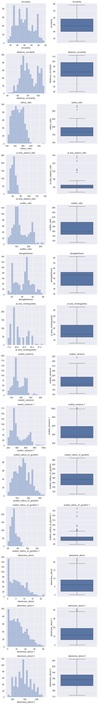

```python
# Plot distributions and box plots of columns that have missing values

num_cols = 2 # Number of columns to plot in the figure
num_rows = len(cols_miss_values) # Number of rows to plot in the figure
fig = plt.figure(figsize = (10, (5 * num_rows)))

for ind, val in enumerate(cols_miss_values):

    sns.set(font_scale = 1.3)
    ax = plt.subplot(num_rows, num_cols ,((2 * ind) + 1))
    sns.distplot(df_temp[val], bins = 20, kde = False)
    ax.set_title(val, fontsize = 15)

    ax = plt.subplot(num_rows, num_cols ,((2 * ind) + 2))
    sns.boxplot(y = val, data = df_temp)
    ax.set_title(val, fontsize = 15)

plt.tight_layout()
plt.show()
```

```python
mean_med_mode_df = pd.DataFrame(df_temp[cols_miss_values].mean(), columns = ['Mean'])
mean_med_mode_df['Median'] = df_temp[cols_miss_values].median()
mean_med_mode_df['Mode'] = df_temp[cols_miss_values].mode().iloc[0]
display(mean_med_mode_df)
```

|  | Mean | Median | Mode |
| --- | --- | --- | --- |
| circularity | 44.8032 | 44.0 | 43.0 |
| distance_circularity | 82.0431 | 79.0 | 66.0 |
| radius_ratio | 169.0984 | 167.0 | 197.0 |
| pr.axis_aspect_ratio | 61.7749 | 61.0 | 64.0 |
| scatter_ratio | 168.5633 | 157.0 | 150.0 |
| elongatedness | 40.9889 | 43.0 | 45.0 |
| pr.axis_rectangularity | 20.5584 | 20.0 | 19.0 |
| scaled_variance | 188.3776 | 179.0 | 170.0 |
| scaled_variance.1 | 438.3825 | 364.0 | 327.0 |
| scaled_radius_of_gyration | 174.2522 | 173.0 | 186.0 |
| scaled_radius_of_gyration.1 | 72.3998 | 71.0 | 72.0 |
| skewness_about | 6.3518 | 6.0 | 0.0 |
| skewness_about.1 | 12.6876 | 11.0 | 11.0 |
| skewness_about.2 | 188.9791 | 189.0 | 187.0 |

**Many of the columns with missing values have right-tailed distributions and also multiple outliers. So, we will replace missing values for all these columns with the medians of the corresponding columns.**

```python
# Replace missing values in all columns with the medians of the corresponding columns
df_orig.fillna(df_orig.median(), inplace = True)
df_orig.isna().sum()
```

```
compactness                    0
circularity                    0
distance_circularity           0
radius_ratio                   0
pr.axis_aspect_ratio           0
max.length_aspect_ratio        0
scatter_ratio                  0
elongatedness                  0
pr.axis_rectangularity         0
max.length_rectangularity      0
scaled_variance                0
scaled_variance.1              0
scaled_radius_of_gyration      0
scaled_radius_of_gyration.1    0
skewness_about                 0
skewness_about.1               0
skewness_about.2               0
hollows_ratio                  0
class                          0
dtype: int64
```

**There are no missing values now. All missing values have been imputed.**

```python
# Re-check descriptive statistics of all columns
df_orig.describe().transpose()
```

|  | count | mean | std | min | 25% | 50% | 75% | max |
| --- | --- | --- | --- | --- | --- | --- | --- | --- |
| compactness | 846.0 | 93.6785 | 8.2345 | 73.0 | 87.00 | 93.0 | 100.00 | 119.0 |
| circularity | 846.0 | 44.8239 | 6.1343 | 33.0 | 40.00 | 44.0 | 49.00 | 59.0 |
| distance_circularity | 846.0 | 82.1005 | 15.7416 | 40.0 | 70.00 | 80.0 | 98.00 | 112.0 |
| radius_ratio | 846.0 | 168.8747 | 33.4014 | 104.0 | 141.00 | 167.0 | 195.00 | 333.0 |
| pr.axis_aspect_ratio | 846.0 | 61.6773 | 7.8822 | 47.0 | 57.00 | 61.0 | 65.00 | 138.0 |
| max.length_aspect_ratio | 846.0 | 8.5674 | 4.6012 | 2.0 | 7.00 | 8.0 | 10.00 | 55.0 |
| scatter_ratio | 846.0 | 168.8877 | 33.1977 | 112.0 | 147.00 | 157.0 | 198.00 | 265.0 |
| elongatedness | 846.0 | 40.9362 | 7.8119 | 26.0 | 33.00 | 43.0 | 46.00 | 61.0 |
| pr.axis_rectangularity | 846.0 | 20.5804 | 2.5886 | 17.0 | 19.00 | 20.0 | 23.00 | 29.0 |
| max.length_rectangularity | 846.0 | 147.9988 | 14.5157 | 118.0 | 137.00 | 146.0 | 159.00 | 188.0 |
| scaled_variance | 846.0 | 188.5969 | 31.3604 | 130.0 | 167.00 | 179.0 | 217.00 | 320.0 |
| scaled_variance.1 | 846.0 | 439.3144 | 176.4963 | 184.0 | 318.25 | 363.5 | 586.75 | 1018.0 |
| scaled_radius_of_gyration | 846.0 | 174.7069 | 32.5463 | 109.0 | 149.00 | 173.5 | 198.00 | 268.0 |
| scaled_radius_of_gyration.1 | 846.0 | 72.4433 | 7.4687 | 59.0 | 67.00 | 71.5 | 75.00 | 135.0 |
| skewness_about | 846.0 | 6.3617 | 4.9032 | 0.0 | 2.00 | 6.0 | 9.00 | 22.0 |
| skewness_about.1 | 846.0 | 12.6005 | 8.9310 | 0.0 | 5.00 | 11.0 | 19.00 | 41.0 |
| skewness_about.2 | 846.0 | 188.9184 | 6.1522 | 176.0 | 184.00 | 188.0 | 193.00 | 206.0 |
| hollows_ratio | 846.0 | 195.6324 | 7.4388 | 181.0 | 190.25 | 197.0 | 201.00 | 211.0 |

# EDA on Dataset

**Let's look at the correlation matrix first to see if there are correlated features.**

## Correlation Matrix

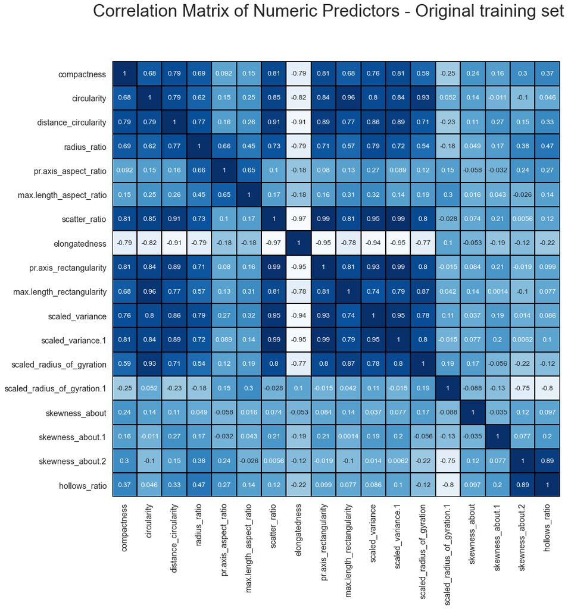

```python
corr_mat = df_orig.corr()
fig = plt.figure(figsize = (14, 14))
fig.suptitle("Correlation Matrix of Numeric Predictors - Original training set", fontsize = 30)
sns.heatmap(corr_mat, annot_kws = {"fontsize": 12}, linewidths = 1,\
            linecolor = 'black', cmap = 'Blues', annot = True ,fmt = '.2g', cbar = False)
plt.show()
```

**Very high correlation seen between multiple features.**

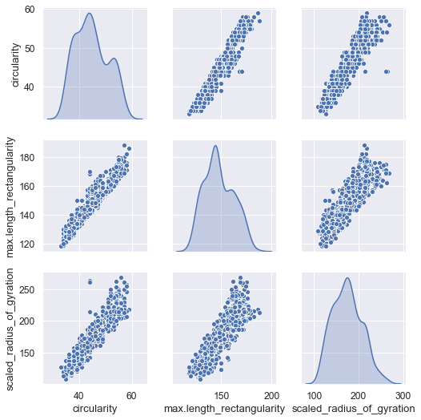

```python
# Look at pair plots of first set of correlated columns
corr_cols = ['circularity', 'max.length_rectangularity', 'scaled_radius_of_gyration']
sns.set(font_scale = 1.1)
sns.pairplot(df_orig, vars = corr_cols, diag_kind='kde')
plt.show()
```

**As can be seen above, the three features, 'circularity', 'max.length_rectangularity' and 'scaled_radius_of_gyration' show high correlation.**

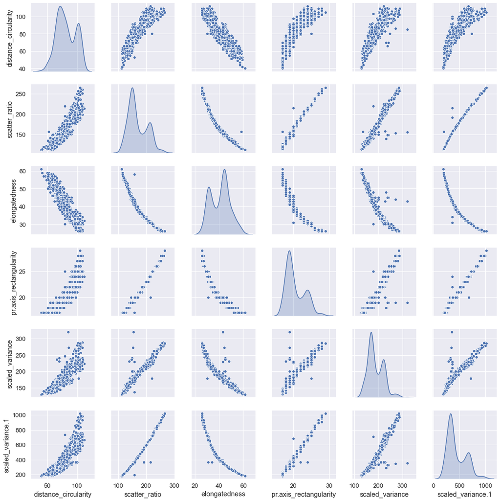

```python
# Look at pair plots of second set of correlated columns
corr_cols = ['distance_circularity', 'scatter_ratio', 'elongatedness', 'pr.axis_rectangularity',\
            'scaled_variance', 'scaled_variance.1']
sns.set(font_scale = 1.2)
sns.pairplot(df_orig, vars = corr_cols, diag_kind='kde')
plt.show()
```

**Again high positive or negative correlation seen between the above features. ('distance_circularity', 'scatter_ratio', 'elongatedness', 'pr.axis_rectangularity', 'scaled_variance', 'scaled_variance.1']**

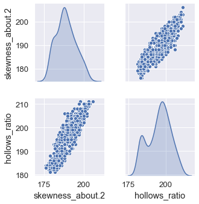

```python
# Look at pair plots of third set of correlated columns
corr_cols = ['skewness_about.2', 'hollows_ratio']
sns.set(font_scale = 1.2)
sns.pairplot(df_orig, vars = corr_cols, diag_kind='kde')
plt.show()
```

**High correlation seen between 'skewness_about.2' and 'hollows_ratio' columns.**

**Since there are many correlated features, we will drop all the correlated features and create a new dataset with reduced features. All the models will be trained on this reduced feature set as well in addition to the original data set with all features retained.**

```python
# List of columns to drop for creating reduced feature training set.
corr_cols_to_drop = ['max.length_rectangularity', 'scaled_radius_of_gyration',\
            'distance_circularity', 'scatter_ratio', 'elongatedness', 'pr.axis_rectangularity',\
            'scaled_variance.1', 'hollows_ratio']
df_red = df_orig.copy()
df_red.drop(columns = corr_cols_to_drop, inplace = True)
df_red.head()
```

|  | compactness | circularity | radius_ratio | pr.axis_aspect_ratio | max.length_aspect_ratio | scaled_variance | scaled_radius_of_gyration.1 | skewness_about | skewness_about.1 | skewness_about.2 | class |
| --- | --- | --- | --- | --- | --- | --- | --- | --- | --- | --- | --- |
| 0 | 95 | 48.0 | 178.0 | 72.0 | 10 | 176.0 | 70.0 | 6.0 | 16.0 | 187.0 | van |
| 1 | 91 | 41.0 | 141.0 | 57.0 | 9 | 170.0 | 72.0 | 9.0 | 14.0 | 189.0 | van |
| 2 | 104 | 50.0 | 209.0 | 66.0 | 10 | 223.0 | 73.0 | 14.0 | 9.0 | 188.0 | car |
| 3 | 93 | 41.0 | 159.0 | 63.0 | 9 | 160.0 | 63.0 | 6.0 | 10.0 | 199.0 | van |
| 4 | 85 | 44.0 | 205.0 | 103.0 | 52 | 241.0 | 127.0 | 9.0 | 11.0 | 180.0 | bus |

```python
df_red.shape
```

```
(846, 11)
```

**Reduced feature set has only 10 features now as compared to 18 features in the original data set.**

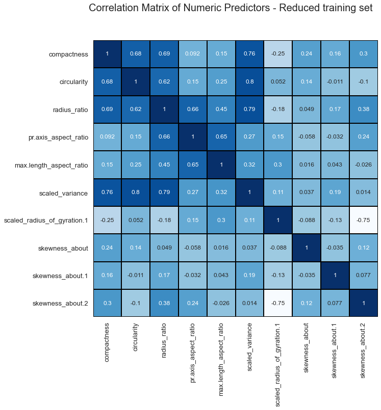

```python
# Re-check correlation matrix of reduced feature training set
corr_mat = df_red.corr()
fig = plt.figure(figsize = (10, 10))
fig.suptitle("Correlation Matrix of Numeric Predictors - Reduced training set", fontsize = 20)
sns.heatmap(corr_mat, annot_kws = {"fontsize": 12}, linewidths = 1,\
            linecolor = 'black', cmap = 'Blues', annot = True ,fmt = '.2g', cbar = False)
plt.show()
```

## Pairplots

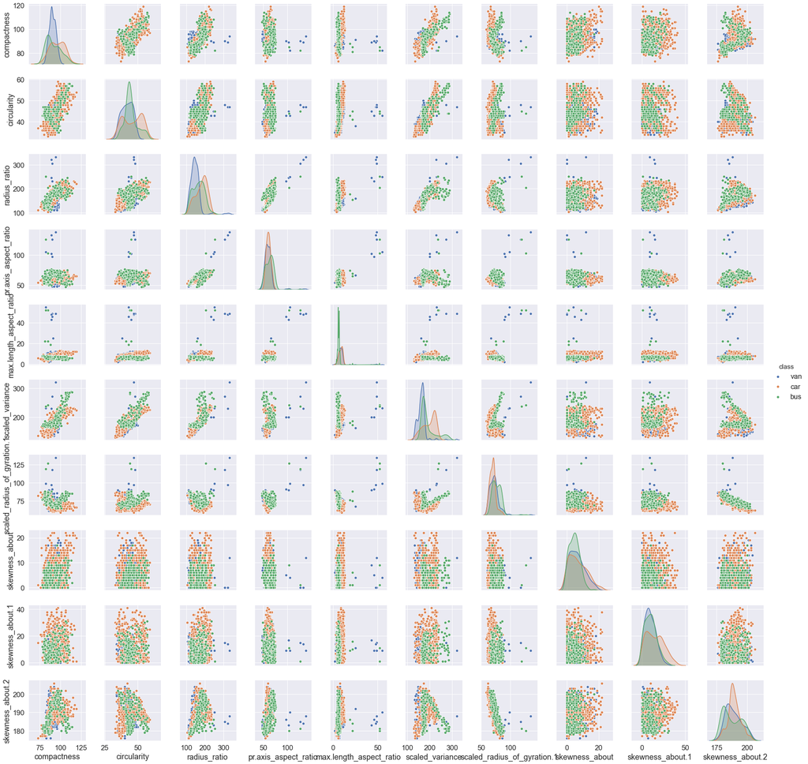

```python
# We will look at pairplots only for the reduced data set.
sns.set(font_scale = 1.5)
sns.pairplot(df_red, hue = 'class', diag_kind='kde')
plt.show()
```

## Statistics of numeric predictors

### Distribution and box plots of Numeric predictors

```python
# Define name of output variable
out_var = 'class'

# Get list of numeric columns
numer_cols = list(df_orig.select_dtypes(include = np.number).columns)

class_van_df = df_orig[df_orig[out_var] == 'van'] # Trimmed dataframe with class = 'van'
class_car_df = df_orig[df_orig[out_var] == 'car'] # Trimmed dataframe with class = 'car'
class_bus_df = df_orig[df_orig[out_var] == 'bus'] # Trimmed dataframe with class = 'bus'
```

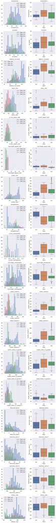

```python
# Initialize figure to plot distributions and box plots of all numeric predictors
num_cols = 2 # Number of columns to plot in the figure
num_rows = len(numer_cols) # Number of rows to plot in the figure
fig = plt.figure(figsize = (10, (5 * num_rows)))

# Plot distribution and boxplots for all numeric perdictors
for ind, val in enumerate(numer_cols):

    sns.set(font_scale = 1.3)
    ax = plt.subplot(num_rows, num_cols ,((2 * ind) + 1))
    sns.distplot(class_van_df[val], bins = 20, kde = False, label = 'Class_van', color = 'r',\
                 ax = ax)
    sns.distplot(class_car_df[val], bins = 20, kde = False, label = 'Class_car', color = 'b',\
                 ax = ax)
    sns.distplot(class_bus_df[val], bins = 20, kde = False, label = 'Class_bus', color = 'g',\
                 ax = ax)
    ax.set_title(val, fontsize = 15)
    ax.legend()

    ax = plt.subplot(num_rows, num_cols ,((2 * ind) + 2))
    sns.boxplot(x = out_var, y = val, data = df_orig, ax = ax)
    ax.set_title(val, fontsize = 15)

plt.tight_layout()
plt.show()
```

### Five-Point Summary, outliers and skew of numerical attributes

```python
fps_out_skew(df_orig, numer_cols)
```

|  | Min | Q1 | Q2 | Q3 | Max | IQR | skew | out_low | out_high | out_tot |
| --- | --- | --- | --- | --- | --- | --- | --- | --- | --- | --- |
| compactness | 73.0 | 87.00 | 93.0 | 100.00 | 119.0 | 13.00 | 0.3806 | 0 | 0 | 0 |
| circularity | 33.0 | 40.00 | 44.0 | 49.00 | 59.0 | 9.00 | 0.2645 | 0 | 0 | 0 |
| distance_circularity | 40.0 | 70.00 | 80.0 | 98.00 | 112.0 | 28.00 | 0.1085 | 0 | 0 | 0 |
| radius_ratio | 104.0 | 141.00 | 167.0 | 195.00 | 333.0 | 54.00 | 0.3969 | 0 | 3 | 3 |
| pr.axis_aspect_ratio | 47.0 | 57.00 | 61.0 | 65.00 | 138.0 | 8.00 | 3.8286 | 0 | 8 | 8 |
| max.length_aspect_ratio | 2.0 | 7.00 | 8.0 | 10.00 | 55.0 | 3.00 | 6.7664 | 1 | 12 | 13 |
| scatter_ratio | 112.0 | 147.00 | 157.0 | 198.00 | 265.0 | 51.00 | 0.6076 | 0 | 0 | 0 |
| elongatedness | 26.0 | 33.00 | 43.0 | 46.00 | 61.0 | 13.00 | 0.0469 | 0 | 0 | 0 |
| pr.axis_rectangularity | 17.0 | 19.00 | 20.0 | 23.00 | 29.0 | 4.00 | 0.7730 | 0 | 0 | 0 |
| max.length_rectangularity | 118.0 | 137.00 | 146.0 | 159.00 | 188.0 | 22.00 | 0.2559 | 0 | 0 | 0 |
| scaled_variance | 130.0 | 167.00 | 179.0 | 217.00 | 320.0 | 50.00 | 0.6544 | 0 | 1 | 1 |
| scaled_variance.1 | 184.0 | 318.25 | 363.5 | 586.75 | 1018.0 | 268.50 | 0.8438 | 0 | 2 | 2 |
| scaled_radius_of_gyration | 109.0 | 149.00 | 173.5 | 198.00 | 268.0 | 49.00 | 0.2794 | 0 | 0 | 0 |
| scaled_radius_of_gyration.1 | 59.0 | 67.00 | 71.5 | 75.00 | 135.0 | 8.00 | 2.0863 | 0 | 15 | 15 |
| skewness_about | 0.0 | 2.00 | 6.0 | 9.00 | 22.0 | 7.00 | 0.7794 | 0 | 12 | 12 |
| skewness_about.1 | 0.0 | 5.00 | 11.0 | 19.00 | 41.0 | 14.00 | 0.6878 | 0 | 1 | 1 |
| skewness_about.2 | 176.0 | 184.00 | 188.0 | 193.00 | 206.0 | 9.00 | 0.2495 | 0 | 0 | 0 |
| hollows_ratio | 181.0 | 190.25 | 197.0 | 201.00 | 211.0 | 10.75 | -0.2259 | 0 | 0 | 0 |

**Summary of above table:**

- Outliers seen in the following features:
  - radius_ratio
  - pr.axis_aspect_ratio
  - max.length_aspect_ratio
  - scaled_variance
  - scaled_variance.1
  - scaled_radius_of_gyration.1
  - skewness_about
  - skewness_about.1
- Very high right-skewed distribution seen in the following features:
  - pr.axis_aspect_ratio
  - max.length_aspect_ratio
  - scaled_radius_of_gyration.1

## Target column distribution

### Count plot of target column

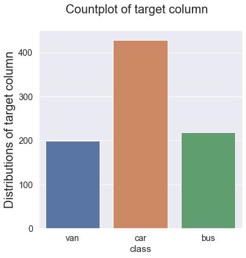

```python
fig = plt.figure(figsize = (6, 6))
fig.suptitle('Countplot of target column', fontsize = 20)

ax1 = plt.subplot(1,1,1)
sns.countplot(df_orig[out_var])
ax1.set_ylabel('Distributions of target column', fontsize = 20)
plt.show()
```

### Value counts of target column

```python
# Compute distribution of positive and negative classes in full dataset
carc_fds = df_orig[out_var].value_counts()[0] # Count of 'car' class: Full dataset
busc_fds = df_orig[out_var].value_counts()[1] # Count of 'bus' class: Full dataset
vanc_fds = df_orig[out_var].value_counts()[2] # Count of 'van' class: Full dataset

print("Full Dataset")
print("============")
print("Number of vehicles in car class: %d (%0.2f %%)"\
      %(carc_fds, (100 * carc_fds / (carc_fds + busc_fds + vanc_fds))))
print("Number of vehicles in bus class: %d (%0.2f %%)"\
      %(busc_fds, (100 * busc_fds / (carc_fds + busc_fds + vanc_fds))))
print("Number of vehicles in van class: %d (%0.2f %%)"\
      %(vanc_fds, (100 * vanc_fds / (carc_fds + busc_fds + vanc_fds))))
```

```
Full Dataset
============
Number of vehicles in car class: 429 (50.71 %)
Number of vehicles in bus class: 218 (25.77 %)
Number of vehicles in van class: 199 (23.52 %)
```

**Bus and van classes contribute about 25% each to the overall dataset. Car class contributes the remaining 50% of the overall dataset.**

# Generate Train / Test sets

- The dataset will now be split into train and test sets in the ratio 70:30.
- Splitting will be stratified using the output variable to maintain the same class distribution in the train and test sets as it is in the original dataset.
- We will generate two sets of training and test sets - one with all the original features (based on df_orig) and one with a reduced feature set obtained by dropping the correlated columns (based on df_red).

## Main set

```python
# Original dataset with all features (based on df_orig)
X = df_orig.drop(columns = out_var)
y = df_orig[out_var]

# Generate train and test datasets
# Training set : test set ratio = 70 : 30, splitting is stratified with the response variable.
X_train, X_test, y_train, y_test = train_test_split(X, y, test_size = 0.3,\
                                                          stratify = y, random_state = 0)
print("X_train.shape: {}" .format(X_train.shape))
print("y_train.shape: {}" .format(y_train.shape))
print("X_test.shape: {}" .format(X_test.shape))
print("y_test.shape: {}" .format(y_test.shape))
```

```
X_train.shape: (592, 18)
y_train.shape: (592,)
X_test.shape: (254, 18)
y_test.shape: (254,)
```

**This training and test set has 18 features for the input variables.**

## Reduced Set

```python
# Reduced dataset with correlated columns dropped (based on df_red)
X_red = df_red.drop(columns = out_var)
y_red = df_red[out_var]

# Generate train and test datasets
# Training set : test set ratio = 70 : 30, splitting is stratified with the response variable.
X_red_train, X_red_test, y_red_train, y_red_test = train_test_split(X_red, y_red, test_size = 0.3,\
                                                          stratify = y_red, random_state = 0)
print("X_red_train.shape: {}" .format(X_red_train.shape))
print("y_red_train.shape: {}" .format(y_red_train.shape))
print("X_red_test.shape: {}" .format(X_red_test.shape))
print("y_red_test.shape: {}" .format(y_red_test.shape))
```

```
X_red_train.shape: (592, 10)
y_red_train.shape: (592,)
X_red_test.shape: (254, 10)
y_red_test.shape: (254,)
```

**This training and test set based on the reduced dataset has 10 input features.**

## Class summary

```python
# Compute distribution of classes in full dataset
carc_fds = df_orig[out_var].value_counts()[0] # Count of 'car' class: Full dataset
busc_fds = df_orig[out_var].value_counts()[1] # Count of 'bus' class: Full dataset
vanc_fds = df_orig[out_var].value_counts()[2] # Count of 'van' class: Full dataset

# Compute distribution of classes in original train and test sets
carc_otrs = y_train.value_counts()[0] # Count of 'car' class: Original training set
busc_otrs = y_train.value_counts()[1] # Count of 'bus' class: Original training set
vanc_otrs = y_train.value_counts()[2] # Count of 'van' class: Original training set
carc_otes = y_test.value_counts()[0] # Count of 'car' class: Original test set
busc_otes = y_test.value_counts()[1] # Count of 'bus' class: Original test set
vanc_otes = y_test.value_counts()[2] # Count of 'van' class: Original test set

# Compute distribution of classes in reduced train and test sets
carc_rtrs = y_red_train.value_counts()[0] # Count of 'car' class: Reduced training set
busc_rtrs = y_red_train.value_counts()[1] # Count of 'bus' class: Reduced training set
vanc_rtrs = y_red_train.value_counts()[2] # Count of 'van' class: Reduced training set
carc_rtes = y_red_test.value_counts()[0] # Count of 'car' class: Reduced test set
busc_rtes = y_red_test.value_counts()[1] # Count of 'bus' class: Reduced test set
vanc_rtes = y_red_test.value_counts()[2] # Count of 'van' class: Reduced test set


print("Full Dataset")
print("============")
print("Number of vehicles in car class: %d (%0.2f %%)"\
      %(carc_fds, (100 * carc_fds / (carc_fds + busc_fds + vanc_fds))))
print("Number of vehicles in bus class: %d (%0.2f %%)"\
      %(busc_fds, (100 * busc_fds / (carc_fds + busc_fds + vanc_fds))))
print("Number of vehicles in van class: %d (%0.2f %%)"\
      %(vanc_fds, (100 * vanc_fds / (carc_fds + busc_fds + vanc_fds))))
print()

print("Original training Set")
print("============")
print("Number of vehicles in car class: %d (%0.2f %%)"\
      %(carc_otrs, (100 * carc_otrs / (carc_otrs + busc_otrs + vanc_otrs))))
print("Number of vehicles in bus class: %d (%0.2f %%)"\
      %(busc_otrs, (100 * busc_otrs / (carc_otrs + busc_otrs + vanc_otrs))))
print("Number of vehicles in van class: %d (%0.2f %%)"\
      %(vanc_otrs, (100 * vanc_otrs / (carc_otrs + busc_otrs + vanc_otrs))))
print()

print("Original test Set")
print("========")
print("Number of vehicles in car class: %d (%0.2f %%)"\
      %(carc_otes, (100 * carc_otes / (carc_otes + busc_otes + vanc_otes))))
print("Number of vehicles in bus class: %d (%0.2f %%)"\
      %(busc_otes, (100 * busc_otes / (carc_otes + busc_otes + vanc_otes))))
print("Number of vehicles in van class: %d (%0.2f %%)"\
      %(vanc_otes, (100 * vanc_otes / (carc_otes + busc_otes + vanc_otes))))
print()

print("Reduced training Set")
print("============")
print("Number of vehicles in car class: %d (%0.2f %%)"\
      %(carc_rtrs, (100 * carc_rtrs / (carc_rtrs + busc_rtrs + vanc_rtrs))))
print("Number of vehicles in bus class: %d (%0.2f %%)"\
      %(busc_rtrs, (100 * busc_rtrs / (carc_rtrs + busc_rtrs + vanc_rtrs))))
print("Number of vehicles in van class: %d (%0.2f %%)"\
      %(vanc_rtrs, (100 * vanc_rtrs / (carc_rtrs + busc_rtrs + vanc_rtrs))))
print()

print("Reduced test Set")
print("========")
print("Number of vehicles in car class: %d (%0.2f %%)"\
      %(carc_rtes, (100 * carc_rtes / (carc_rtes + busc_rtes + vanc_rtes))))
print("Number of vehicles in bus class: %d (%0.2f %%)"\
      %(busc_rtes, (100 * busc_rtes / (carc_rtes + busc_rtes + vanc_rtes))))
print("Number of vehicles in van class: %d (%0.2f %%)"\
      %(vanc_rtes, (100 * vanc_rtes / (carc_rtes + busc_rtes + vanc_rtes))))
print()
```

```
Full Dataset
============
Number of vehicles in car class: 429 (50.71 %)
Number of vehicles in bus class: 218 (25.77 %)
Number of vehicles in van class: 199 (23.52 %)

Original training Set
============
Number of vehicles in car class: 300 (50.68 %)
Number of vehicles in bus class: 153 (25.84 %)
Number of vehicles in van class: 139 (23.48 %)

Original test Set
========
Number of vehicles in car class: 129 (50.79 %)
Number of vehicles in bus class: 65 (25.59 %)
Number of vehicles in van class: 60 (23.62 %)

Reduced training Set
============
Number of vehicles in car class: 300 (50.68 %)
Number of vehicles in bus class: 153 (25.84 %)
Number of vehicles in van class: 139 (23.48 %)

Reduced test Set
========
Number of vehicles in car class: 129 (50.79 %)
Number of vehicles in bus class: 65 (25.59 %)
Number of vehicles in van class: 60 (23.62 %)
```

**The above data indicates that the train and test splits have been done while maintaining the class ratio.**

# PCA

- In this section, we will perform PCA on the feature set to identify the number of dimensions needed to achieve 95% and 99% explained variance ratios.
- For this analysis, PCA is performed on the entire dataset. However, while training the models using cross-validation, PCA will be fitted only on the training folds. This fit will then be used to transform both training and validation folds. This is to avoid leakage from the validation folds to the training folds. The same fit will also be used to transform the test set while estimating classification accuracy on the test set.

```python
# Start with number of principal components = number of features.
tot_num_pc = X.shape[1]

# Create pipeline with Standard Scaler and PCA with number of components = number of features.
pipe_pca = make_pipeline(StandardScaler(), PCA(n_components = tot_num_pc))

# Fit PCA on the input feature set.
pipe_pca.fit(X)
```

```
Pipeline(steps=[('standardscaler', StandardScaler()),
                ('pca', PCA(n_components=18))])
```

**Plot eigen values in descending order of variation explained.**

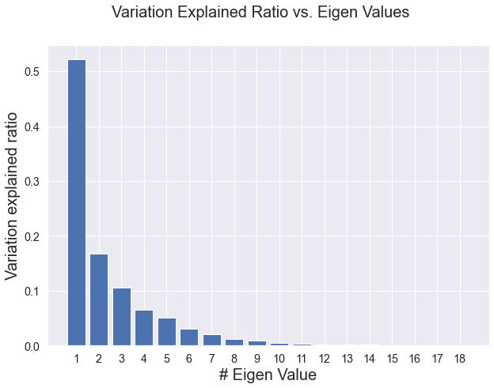

```python
fig = plt.figure(figsize = (10, 7))
fig.suptitle('Variation Explained Ratio vs. Eigen Values', fontsize = 20)
plt.bar(list(range(1, (tot_num_pc + 1))),\
        pipe_pca.named_steps['pca'].explained_variance_ratio_, align='center')
plt.ylabel('Variation explained ratio', fontsize = 20)
plt.xlabel('# Eigen Value', fontsize = 20)
plt.xticks(ticks = list(range(1, (tot_num_pc + 1))))
plt.show()
```

**Plot cumulative sum of eigen values.**

```
The number of principal components required to explain 95% of the variance in the input data is 7
The number of principal components required to explain 99% of the variance in the input data is 11
```

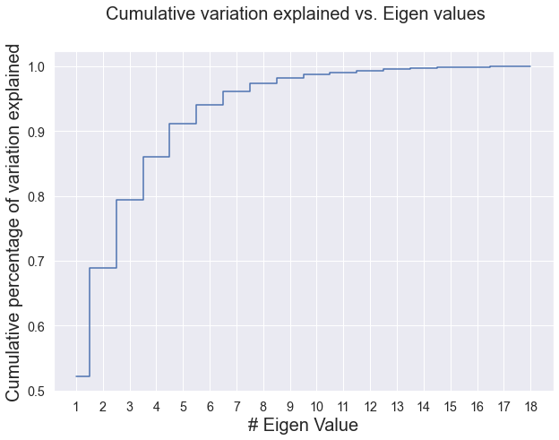

```python
# Calculate cumulative sum of explained variance ratio
exp_var_rat = pipe_pca.named_steps['pca'].explained_variance_ratio_
cum_sum_exp_var_rat = np.cumsum(exp_var_rat)

# Find number of principal components needed to explain 95% of the variance
num_pc_95per = np.where(cum_sum_exp_var_rat > 0.95)[0][0] + 1
num_pc_99per = np.where(cum_sum_exp_var_rat > 0.99)[0][0] + 1
print("The number of principal components required to explain 95%% of the variance \
in the input data is %d" % num_pc_95per)
print("The number of principal components required to explain 99%% of the variance \
in the input data is %d" % num_pc_99per)

fig = plt.figure(figsize = (10, 7))
fig.suptitle('Cumulative variation explained vs. Eigen values', fontsize = 20)
plt.step(list(range(1, (tot_num_pc + 1))), cum_sum_exp_var_rat, where = 'mid')
plt.ylabel('Cumulative percentage of variation explained', fontsize = 20)
plt.xlabel('# Eigen Value', fontsize = 20)
plt.xticks(ticks = list(range(1, (tot_num_pc + 1))))
plt.show()
```

**Print Summary of explained variance of PCA analysis.**

```python
pca_sum_df = pd.DataFrame(exp_var_rat, index = list(range(1, (tot_num_pc + 1))),\
                          columns = ['Explained_Variance_Ratio'])
pca_sum_df['Cumulative_Explained_Variance_Ratio'] = cum_sum_exp_var_rat
pca_sum_df.index.name = '# Eigen_Value'
pca_sum_df.head(tot_num_pc)
```

| # Eigen_Value | Explained_Variance_Ratio | Cumulative_Explained_Variance_Ratio |
| --- | --- | --- |
| 1 | 0.5219 | 0.5219 |
| 2 | 0.1673 | 0.6892 |
| 3 | 0.1056 | 0.7948 |
| 4 | 0.0655 | 0.8603 |
| 5 | 0.0509 | 0.9112 |
| 6 | 0.0300 | 0.9411 |
| 7 | 0.0199 | 0.9610 |
| 8 | 0.0123 | 0.9734 |
| 9 | 0.0089 | 0.9823 |
| 10 | 0.0051 | 0.9874 |
| 11 | 0.0037 | 0.9910 |
| 12 | 0.0026 | 0.9936 |
| 13 | 0.0020 | 0.9956 |
| 14 | 0.0015 | 0.9971 |
| 15 | 0.0011 | 0.9983 |
| 16 | 0.0010 | 0.9993 |
| 17 | 0.0006 | 0.9998 |
| 18 | 0.0002 | 1.0000 |

**In summary, seven principal components are required to explain 95% of the variance in the input data and 11 principal components are required to explain 99% of the variance in the input data.**

# Models - Fit and Evaluate

- In this section, we fit all the models defined in the **Init Classifier** function above. Classification accuracy evaluated on the training and test sets are printed and summarized.
- The models will be fit on four different training sets:
  - Original training set with all 18 features (based on df_orig).
  - Reduced feature training set with only 10 features included (based on df_red). Remaining 8 features are dropped based on high correlation with one of the other 10 features.
  - Dimensionality reduced training set using PCA with 7 principal components included (explains 95% of the variance in the input data).
  - Dimensionality reduced training set using PCA with 11 principal components included (explains 99% of the variance in the input data).

## Initialize fitted Classifiers

```python
# Initialize all classifiers
clfs = clf_define()

# Initialize list of fitted classifiers with 'None' values

# Original training set - Standard Scaler - No dimensionality reduction
clfs_fit_orig = [None for ind in range(len(clf_define()))]

# Reduced training set - Some features dropped based on correlation matrix
clfs_fit_red = [None for ind in range(len(clf_define()))]

# Original training set - Standard Scaler - Dimensionality reduced using PCA at 95% and 99%
clfs_fit_pca_0p95 = [None for ind in range(len(clf_define()))]
clfs_fit_pca_0p99 = [None for ind in range(len(clf_define()))]
```

## Initialize grid / random search parameters

```python
# Initialize all classifiers
clfs = clf_define()

# Define scalers to use on all numeric columns
sc1 = MinMaxScaler()
sc2 = StandardScaler()
sc3 = RobustScaler()
sc4 = None

# Define PCA with reduced dimensions for 95% and 99% explained variance
# PCA with either 7 or 11 components will be used along with standard scaler in a pipeline
# to do cross-validation on the training set.
# During cross-validation, the PCA will be fitted only on the training folds. The evaluated
# eigenvectors after fitting will then be used to transform both the training folds and the
# cross-validation folds.
# The same eigenvectors will also be used to transform the test data when evaluating
# classification accuracy on the test set.
num_pc_0p95 = 7 # 7 PCA components needed to explain 95% of variance in input features
pca_red_dim_0p95 = PCA(n_components = num_pc_0p95)
num_pc_0p99 = 11 # 11 PCA components needed to explain 99% of variance in input features
pca_red_dim_0p99 = PCA(n_components = num_pc_0p99)

# Create list of different pre-processing steps
pp1 = [('scal_1', sc2)] # Only standard scaling of features - no PCA
pp2 = [('scal_1', sc2), ('pca', pca_red_dim_0p95)] # Standard Scaling + PCA - 95%
pp3 = [('scal_1', sc2), ('pca', pca_red_dim_0p99)] # Standard Scaling + PCA - 99%

# Pre-processing steps for each classifier
pre_proc_1 = [pp1 for ind in range(len(clfs))] # Only standard scaling of features - no PCA
pre_proc_2 = [pp2 for ind in range(len(clfs))] # Standard Scaling + PCA - 95%
pre_proc_3 = [pp3 for ind in range(len(clfs))] # Standard Scaling + PCA - 99%

# Define type of cross-validation to perform for each classifier
    # 0: Dont run any hyperparameter search (Use this only if the classifier has been fit already)
    # 1: Run Grid Search CV
    # 2: Run Randomized Search CV
cv_type = [1 for ind in range(len(clfs))]
#cv_type = [0, 0, 0, 0, 0, 0, 0, 0, 0, 1]

# Define number of parameter settings to sample while running Randomized Search CV.
num_iter = [10 for ind in range(len(clfs))]

# Define number of cross-validations to perform for each classifier
num_cv = [5 for ind in range(len(clfs))]

# Define whether to perform coarse of fine search for each classifier
    # 0: Perform coarse search, use 'param_grid_coarse' from the classifier dictionary
    # 1: Perform fine search, use 'param_grid_fine' from the classifier dictionary
#cf = [0 for ind in range(len(clfs))]
cf = [0, 0, 0, 1, 0, 0, 0, 1, 0, 1]
```

## Run grid / random search CV

```python
# Run grid / random search CV on original training set with standard scaler alone
# No dimensionality reduction
clfs_fit_orig = model_fit(clfs, clfs_fit_orig, X_train, y_train, pre_proc_1, cv_type,\
                          cf, num_cv, num_iter)
```

```
Fitting Classifier 0...., Fitting Completed. Elapsed time = 1.42 seconds
Fitting Classifier 1...., Fitting Completed. Elapsed time = 0.08 seconds
Fitting Classifier 2...., Fitting Completed. Elapsed time = 4.89 seconds
Fitting Classifier 3...., Fitting Completed. Elapsed time = 2.64 seconds
Fitting Classifier 4...., Fitting Completed. Elapsed time = 12.58 seconds
Fitting Classifier 5...., Fitting Completed. Elapsed time = 12.19 seconds
Fitting Classifier 6...., Fitting Completed. Elapsed time = 39.25 seconds
Fitting Classifier 7...., Fitting Completed. Elapsed time = 81.45 seconds
Fitting Classifier 8...., Fitting Completed. Elapsed time = 40.91 seconds
Fitting Classifier 9...., Fitting Completed. Elapsed time = 281.09 seconds
```

```python
# Run grid / random search CV on reduced training set with standard scaler alone
# No dimensionality reduction
clfs_fit_red = model_fit(clfs, clfs_fit_red, X_red_train, y_red_train, pre_proc_1, cv_type,\
                         cf, num_cv, num_iter)
```

```
Fitting Classifier 0...., Fitting Completed. Elapsed time = 1.09 seconds
Fitting Classifier 1...., Fitting Completed. Elapsed time = 0.09 seconds
Fitting Classifier 2...., Fitting Completed. Elapsed time = 4.25 seconds
Fitting Classifier 3...., Fitting Completed. Elapsed time = 2.58 seconds
Fitting Classifier 4...., Fitting Completed. Elapsed time = 10.36 seconds
Fitting Classifier 5...., Fitting Completed. Elapsed time = 10.97 seconds
Fitting Classifier 6...., Fitting Completed. Elapsed time = 33.03 seconds
Fitting Classifier 7...., Fitting Completed. Elapsed time = 81.42 seconds
Fitting Classifier 8...., Fitting Completed. Elapsed time = 36.81 seconds
Fitting Classifier 9...., Fitting Completed. Elapsed time = 207.75 seconds
```

```python
# Run grid / random search CV on original training set with standard scaler + PCA - 95%
clfs_fit_pca_0p95 = model_fit(clfs, clfs_fit_pca_0p95, X_train, y_train, pre_proc_2, cv_type,\
                         cf, num_cv, num_iter)
```

```
Fitting Classifier 0...., Fitting Completed. Elapsed time = 1.14 seconds
Fitting Classifier 1...., Fitting Completed. Elapsed time = 0.08 seconds
Fitting Classifier 2...., Fitting Completed. Elapsed time = 4.22 seconds
Fitting Classifier 3...., Fitting Completed. Elapsed time = 98.17 seconds
Fitting Classifier 4...., Fitting Completed. Elapsed time = 10.34 seconds
Fitting Classifier 5...., Fitting Completed. Elapsed time = 13.19 seconds
Fitting Classifier 6...., Fitting Completed. Elapsed time = 36.48 seconds
Fitting Classifier 7...., Fitting Completed. Elapsed time = 104.67 seconds
Fitting Classifier 8...., Fitting Completed. Elapsed time = 40.50 seconds
Fitting Classifier 9...., Fitting Completed. Elapsed time = 237.62 seconds
```

```python
# Run grid / random search CV on original training set with standard scaler + PCA - 99%
clfs_fit_pca_0p99 = model_fit(clfs, clfs_fit_pca_0p99, X_train, y_train, pre_proc_3, cv_type,\
                         cf, num_cv, num_iter)
```

```
Fitting Classifier 0...., Fitting Completed. Elapsed time = 1.33 seconds
Fitting Classifier 1...., Fitting Completed. Elapsed time = 0.09 seconds
Fitting Classifier 2...., Fitting Completed. Elapsed time = 4.45 seconds
Fitting Classifier 3...., Fitting Completed. Elapsed time = 2.98 seconds
Fitting Classifier 4...., Fitting Completed. Elapsed time = 11.25 seconds
Fitting Classifier 5...., Fitting Completed. Elapsed time = 14.58 seconds
Fitting Classifier 6...., Fitting Completed. Elapsed time = 43.16 seconds
Fitting Classifier 7...., Fitting Completed. Elapsed time = 105.70 seconds
Fitting Classifier 8...., Fitting Completed. Elapsed time = 42.86 seconds
Fitting Classifier 9...., Fitting Completed. Elapsed time = 314.25 seconds
```

```python
# This section is for iterating on the grid / random search CV process.

# clf_ind = 9
# cv_df = cv_results_summary(clfs_fit_red, clf_ind)

# param_1 = 'param_clf__n_estimators'
# param_2 = 'param_clf__max_depth'
# param_3 = 'param_clf__gamma'

# cv_df = cv_df[cv_df[param_1] == 300]
# cv_df = cv_df[cv_df[param_2] == 2]
# display(cv_df)

# xaxis = cv_df[param_2]
# yaxis_1 = cv_df['mean_train_score']
# yaxis_2 = cv_df['mean_test_score']
# plt.figure(figsize = (8, 8))
# plt.plot(xaxis, yaxis_1, 'b-*', label = 'Training_Set')
# plt.plot(xaxis, yaxis_2, 'r-*', label = 'Test_Set')
# # plt.xscale('log')
# plt.legend(loc = 'best')
# plt.show()

# cv_df.sort_values(by = 'mean_train_score', ascending = False)
#cv_df.sort_values(by = 'rank_test_score')
# cv_df.sort_values(by = 'rank_test_score').head(10)
# cv_df.sort_values(by = param_1)
# clfs_fit[clf_ind].best_estimator_
```

## Evaluate Models

This section will evaluate all the models that have been fit above using grid / random search.

```python
# Original training set with standard scaler alone - No dimensionality reduction
ms_orig_df = model_eval_mc(clfs, clfs_fit_orig, X_train, y_train, X_test, y_test, True)
```

```
Classification_Accuracy_Summary
===============================
```

|  | CV_Score(%) | Train_Score(%) | Test_Score(%) |
| --- | --- | --- | --- |
| Logistic_Regression_Without_Class_Weights | 95.6075 | 97.1284 | 93.3071 |
| Gaussian_Naive_Bayes | 61.3118 | 60.9797 | 61.4173 |
| K_Nearest_Neighbors | 90.7121 | 100.0000 | 93.3071 |
| SVM_With_Poly_Kernel | 92.7347 | 100.0000 | 96.8504 |
| SVM_With_RBF_Kernel | 97.6342 | 99.3243 | 98.0315 |
| Decision_Tree_Classifier | 90.5313 | 100.0000 | 90.1575 |
| Bagging_Classifier | 93.0708 | 100.0000 | 95.2756 |
| Random_Forest_Classifer | 96.2854 | 100.0000 | 95.6693 |
| Adaptive_Boosting_Classifier | 87.3266 | 86.1486 | 87.4016 |
| Gradient_Boosting_Classifier | 96.6216 | 100.0000 | 96.0630 |

```python
# Reduced training set with standard scaler alone - No dimensionality reduction
ms_red_df = model_eval_mc(clfs, clfs_fit_red, X_red_train, y_red_train, X_red_test, y_red_test, True)
```

```
Classification_Accuracy_Summary
===============================
```

|  | CV_Score(%) | Train_Score(%) | Test_Score(%) |
| --- | --- | --- | --- |
| Logistic_Regression_Without_Class_Weights | 91.5511 | 92.3986 | 90.9449 |
| Gaussian_Naive_Bayes | 67.5588 | 68.7500 | 73.6220 |
| K_Nearest_Neighbors | 86.3196 | 100.0000 | 90.5512 |
| SVM_With_Poly_Kernel | 91.8915 | 96.9595 | 92.1260 |
| SVM_With_RBF_Kernel | 96.1159 | 97.6351 | 94.4882 |
| Decision_Tree_Classifier | 87.4947 | 97.9730 | 88.5827 |
| Bagging_Classifier | 91.8872 | 100.0000 | 94.0945 |
| Random_Forest_Classifer | 94.0849 | 100.0000 | 96.8504 |
| Adaptive_Boosting_Classifier | 83.9539 | 86.3176 | 83.8583 |
| Gradient_Boosting_Classifier | 94.0863 | 100.0000 | 94.4882 |

```python
# Original training set with standard scaler + PCA - 95%
ms_pca_0p95_df = model_eval_mc(clfs, clfs_fit_pca_0p95, X_train, y_train, X_test, y_test, True)
```

```
Classification_Accuracy_Summary
===============================
```

|  | CV_Score(%) | Train_Score(%) | Test_Score(%) |
| --- | --- | --- | --- |
| Logistic_Regression_Without_Class_Weights | 79.5556 | 79.2230 | 82.6772 |
| Gaussian_Naive_Bayes | 72.9796 | 72.6351 | 72.8346 |
| K_Nearest_Neighbors | 86.4834 | 100.0000 | 89.3701 |
| SVM_With_Poly_Kernel | 85.3012 | 96.7905 | 90.5512 |
| SVM_With_RBF_Kernel | 92.5652 | 94.4257 | 94.4882 |
| Decision_Tree_Classifier | 81.4286 | 98.3108 | 79.9213 |
| Bagging_Classifier | 86.9905 | 100.0000 | 92.1260 |
| Random_Forest_Classifer | 89.0229 | 100.0000 | 92.5197 |
| Adaptive_Boosting_Classifier | 81.9271 | 85.9797 | 84.2520 |
| Gradient_Boosting_Classifier | 88.5145 | 100.0000 | 92.1260 |

```python
# Original training set with standard scaler + PCA - 99%
ms_pca_0p99_df = model_eval_mc(clfs, clfs_fit_pca_0p99, X_train, y_train, X_test, y_test, True)
```

```
Classification_Accuracy_Summary
===============================
```

|  | CV_Score(%) | Train_Score(%) | Test_Score(%) |
| --- | --- | --- | --- |
| Logistic_Regression_Without_Class_Weights | 91.5539 | 91.7230 | 91.3386 |
| Gaussian_Naive_Bayes | 83.6120 | 85.6419 | 82.2835 |
| K_Nearest_Neighbors | 90.5441 | 100.0000 | 91.3386 |
| SVM_With_Poly_Kernel | 91.2107 | 99.3243 | 94.4882 |
| SVM_With_RBF_Kernel | 97.2967 | 99.3243 | 96.8504 |
| Decision_Tree_Classifier | 85.4779 | 100.0000 | 84.6457 |
| Bagging_Classifier | 92.7318 | 100.0000 | 91.3386 |
| Random_Forest_Classifer | 94.0863 | 100.0000 | 92.1260 |
| Adaptive_Boosting_Classifier | 88.1712 | 91.7230 | 89.7638 |
| Gradient_Boosting_Classifier | 95.6046 | 100.0000 | 93.7008 |

## Summary of all Models

- **Hyperparameters for all classifiers are chosen based on coarse / fine grid search with 5-fold cross-validation.**
- Almost all the classifiers (except for Naive Bayes) show the best performance with the original training set which has all the original features retained (18 features).
- Next best performance is achieved when PCA is applied with 11 extracted dimensions (99% variance explained) or using a reduced feature set (obtained by dropping 8 features from the feature set based on the correlation matrix).
- Finally, using PCA with 7 extracted dimensions (95% variance explained) shows the lowest performance.
- **Best performance among all classifiers is achieved using SVM with RBF kernel and the original training set (hyperparameters: C = 100, gamma = 0.01). Mean training set score with 5-fold CV is 99% and the mean CV score is 97.6%. On the test set, 98% accuracy is achieved.**
- When PCA is applied with 11 dimensions selected (99% explained variance), the test set classification accuracy drops to about 97%
- PCA with 7 dimensions selected (95% explained variance) or using the reduced training set (10 features only retained) results in a 94.5% accuracy on the test set.
- **In contrast to the other classifiers, Gaussian Naive Bayes performs worst on the original training set. Since there are many correlated features which violates the assumption of independence required for naive Bayes, performance with the original training set is poor. With PCA applied, the performance improves as PCA is able to extract independent components from the training set.**

# Backup - Ignore

```python
# Temp Checking
# ind = 0
# clfs_fit[ind].best_estimator_
# scaler_temp = MinMaxScaler()
# scaler_temp.fit(X_train)
# X_train_sc = scaler_temp.transform(X_train)
# X_test_sc = scaler_temp.transform(X_test)
# clf_temp = LogisticRegression(C=500, solver='liblinear')
# pipe_temp = make_pipeline(MinMaxScaler(), LogisticRegression(C=500, solver='liblinear'))

# y_pred_1 = clf_temp.fit(X_train_sc, y_train).predict(X_train_sc)
# y_pred_2 = pipe_temp.fit(X_train, y_train).predict(X_train)
# print(np.sum(y_pred_1 != y_pred_2))

# print("%0.6f" % (clf_temp.fit(X_train_sc, y_train).score(X_train_sc, y_train)))
# print("%0.6f" % (pipe_temp.fit(X_train, y_train).score(X_train, y_train)))
# print()
# print("%0.6f" % (clf_temp.fit(X_train_sc, y_train).score(X_test_sc, y_test)))
# print("%0.6f" % (pipe_temp.fit(X_train, y_train).score(X_test, y_test)))
```

```python
# # Define list of all classifiers
# clfs = clf_define()

# # Define scaler to use on all numeric columns
# sc1 = MinMaxScaler()
# sc2 = StandardScaler()
# sc3 = RobustScaler()
# sc4 = None

# # Define PCA with reduced dimensions
# num_pc = 7
# pca_red_dim = PCA(n_components = num_pc)

# pre_proc_1 = [('scal_1', sc2), ('pca', pca_red_dim)]

# # Pre-processing steps for each classifier
# pre_proc = [pre_proc_1 for ind in range(len(clfs))]

# # Define type of cross-validation to perform for each classifier
#     # 0: Dont run any hyperparameter search (Use this only if the classifier has been fit already)
#     # 1: Run Grid Search CV
#     # 2: Run Randomized Search CV
# cv_type = [1 for ind in range(len(clfs))]
# #cv_type = [1, 1, 1, 0, 1, 1, 1, 1, 1, 1]

# # Define number of parameter settings to sample while running Randomized Search CV.
# num_iter = [10 for ind in range(len(clfs))]

# # Define number of cross-validations to perform for each classifier
# num_cv = [5 for ind in range(len(clfs))]

# # Define whether to perform coarse of fine search for each classifier
#     # 0: Perform coarse search, use 'param_grid_coarse' from the classifier dictionary
#     # 1: Perform fine search, use 'param_grid_fine' from the classifier dictionary
# cf = [0 for ind in range(len(clfs))]
# #cf = [0, 0, 0, 0, 0, 0, 0, 0, 0, 1, 1, 1]
```

```python
# Temp Checking
# pipe_pca_temp = make_pipeline(StandardScaler(), PCA(n_components = 7),\
#                               SVC(kernel='poly'))
# #pipe_pca_temp.fit(X_train, y_train)
# #pipe_pca_temp.score(X_test, y_test)
# pg_temp = {'svc__C': [0.01, 0.1, 1, 10, 100, 1000],
#                      'svc__degree': list(range(3, 7, 1)),
#                      'svc__gamma': [0.001, 0.01, 0.1, 1, 10, 100, 1000]
#                     }
# grid_temp = GridSearchCV(pipe_pca_temp, pg_temp, cv = 5, return_train_score = True, verbose = 2)
# grid_temp.fit(X_train, y_train)
# clf_temp = LogisticRegression(C=500, solver='liblinear')
# pipe_temp = make_pipeline(MinMaxScaler(), LogisticRegression(C=500, solver='liblinear'))

# y_pred_1 = clf_temp.fit(X_train_sc, y_train).predict(X_train_sc)
# y_pred_2 = pipe_temp.fit(X_train, y_train).predict(X_train)
# print(np.sum(y_pred_1 != y_pred_2))

# print("%0.6f" % (clf_temp.fit(X_train_sc, y_train).score(X_train_sc, y_train)))
# print("%0.6f" % (pipe_temp.fit(X_train, y_train).score(X_train, y_train)))
# print()
# print("%0.6f" % (clf_temp.fit(X_train_sc, y_train).score(X_test_sc, y_test)))
# print("%0.6f" % (pipe_temp.fit(X_train, y_train).score(X_test, y_test)))
```

```python
# clfs_fit_pca = model_fit_upd(clfs, clfs_fit, X_train, y_train, pre_proc, cv_type,\
#                              cf, num_cv, num_iter)
```

```python
# model_eval_mc(clfs, clfs_fit_pca, X_train, y_train, X_test, y_test, True)
```

```python
# pipe_temp = make_pipeline(sc2, PCA(n_components = 7), clfs[0][0])
# pg_temp = {'logisticregression__C': [0.01, 0.05, 0.1, 0.5, 1, 5, 10, 25, 50, 75, 100, 500, 1000]}
# grid_temp = GridSearchCV(pipe_temp, pg_temp, cv = 5, return_train_score = True)
# grid_temp.fit(X_train, y_train)
# cv_res_df_temp = pd.DataFrame(grid_temp.cv_results_)
# cols = []
# for ind, val in enumerate(list(cv_res_df_temp.columns)):
#     if (('param_' in val) or ('mean_t' in val) or ('rank_' in val)):
#         cols.append(val)
# cv_res_df_temp = cv_res_df_temp[cols]
# display(cv_res_df_temp.sort_values(by = 'rank_test_score'))
# grid_temp.best_estimator_.fit(X_train, y_train).score(X_train, y_train)
```

```python
# # This section is for iterating on the grid / random search CV process.

# clf_ind = 0
# cv_df = cv_results_summary(clfs_fit, clf_ind)

# param_1 = 'param_clf__C'
# # param_2 = 'param_svc__C'
# # param_3 = 'param_svc__gamma'

# # cv_df = cv_df[cv_df[param_1] == 100]
# # cv_df = cv_df[cv_df[param_2] == 1]
# # display(cv_df)

# xaxis = cv_df[param_1]
# yaxis_1 = cv_df['mean_train_score']
# yaxis_2 = cv_df['mean_test_score']
# plt.figure(figsize = (8, 8))
# plt.plot(xaxis, yaxis_1, 'b-*', label = 'Training_Set')
# plt.plot(xaxis, yaxis_2, 'r-*', label = 'Test_Set')
# plt.xscale('log')
# plt.legend(loc = 'best')
# plt.show()

# # cv_df.sort_values(by = 'mean_train_score', ascending = False)
# cv_df.sort_values(by = 'rank_test_score')
# # cv_df.sort_values(by = param_1)
# # clfs_fit[clf_ind].best_estimator_
```

```python
# clfs_fit_orig[5]
```

```python
# DecisionTreeClassifier(random_state = 0, criterion = 'entropy',\
#                        max_depth = 14, min_samples_split = 2).\
# fit(X_train, y_train).score(X_test, y_test)
```

```python
# X_sc = StandardScaler().fit_transform(X)
# print(LogisticRegression(C = 500, solver = 'liblinear').fit(X_sc, y).score(X_sc, y))
```

```python
# LogisticRegression(C = 500, solver = 'liblinear').fit(X_red, y_red).score(X_red, y_red)
```

```python
# num_pc = 7
# pca_temp = PCA(n_components = num_pc).fit(X_sc)
# X_pca = pca_temp.transform(X_sc)
# X_pca_train, X_pca_test, y_pca_train, y_pca_test = train_test_split(X_pca, y, test_size = 0.3,\
#                                                           stratify = y, random_state=0)
```

```python
# print(DecisionTreeClassifier(random_state = 0, criterion = 'entropy',\
#                        max_depth = 14, min_samples_split = 2).\
#       fit(X_pca_train, y_pca_train).score(X_pca_test, y_pca_test))
```